# homework 3

Josh

4/19/2021

```r
library(tidyverse)
```

```r
library(dplyr)
library(ggplot2)
library(reshape2)
library(infer)
library(broom)
library(ggpubr)
df <- read.csv("KamilarAndCooperData.csv")
df_lm <- df[c("WeaningAge_d", "Brain_Size_Species_Mean")] %>% drop_na()
head(df)
```

```
##               Scientific_Name          Family          Genus      Species
## 1 Allenopithecus_nigroviridis Cercopithecidae Allenopithecus nigroviridis
## 2         Allocebus_trichotis Cercopithecidae      Allocebus    trichotis
## 3           Alouatta_belzebul        Atelidae       Alouatta     belzebul
## 4             Alouatta_caraya        Atelidae       Alouatta       caraya
## 5            Alouatta_guariba        Atelidae       Alouatta      guariba
## 6           Alouatta_palliata        Atelidae       Alouatta     palliata
##   Brain_Size_Species_Mean Brain_Size_Female_Mean   Brain_size_Ref
## 1                   58.02                  53.70 Isler et al 2008
## 2                      NA                     NA
## 3                   52.84                  51.19 Isler et al 2008
## 4                   52.63                  47.80 Isler et al 2008
## 5                   51.70                  49.08 Isler et al 2008
## 6                   49.88                  48.04 Isler et al 2008
##   Body_mass_male_mean Body_mass_female_mean Mass_Dimorphism
```

[output cut: 62 more lines]

challenge 1

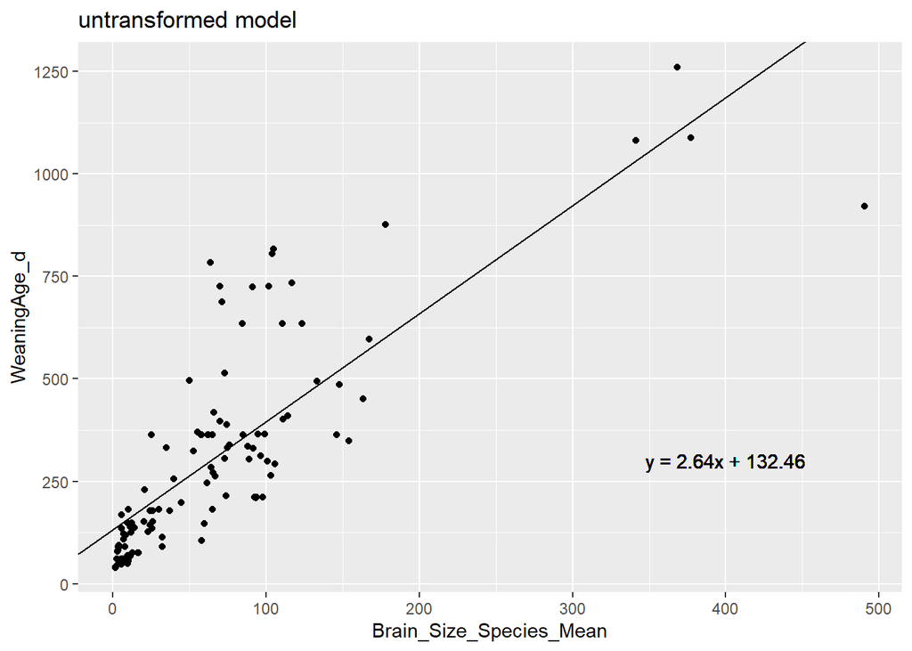

```r
#weaning age ~ brain size model
lm_m <- lm(WeaningAge_d ~ Brain_Size_Species_Mean, data = df_lm)

g <-ggplot(data = df_lm, aes(x = Brain_Size_Species_Mean, y = WeaningAge_d)) +
  geom_point() +
  geom_abline(slope = lm_m$coefficients[2],intercept = lm_m$coefficients[1]) +
  geom_text(x = 400, y = 300, label = paste0("y = ",round(lm_m$coefficients[2], digits = 2), "x + ", round(lm_m$coefficients[1],digits = 2))) +
  ggtitle("untransformed model")
g
```

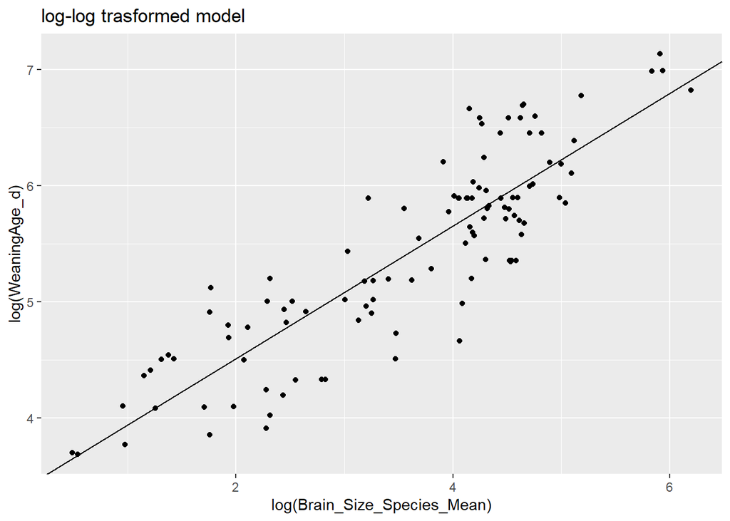

```r
#log(weaning age) ~ brain size model
log_m <- lm(log(WeaningAge_d)~log(Brain_Size_Species_Mean), data = df_lm)

g_log <- ggplot(data = df_lm, aes(x = log(Brain_Size_Species_Mean), y = log(WeaningAge_d))) +
  geom_point() +
  geom_abline(slope = log_m$coefficients[2], intercept = log_m$coefficients[1])+
  geom_text(x = 400, y = 300, label = paste0("y = ", round(log_m$coefficients[2], digits = 2),"x + ",round(log_m$coefficients[1],digits = 2)))+
  ggtitle("log-log trasformed model")

g_log
```

Identify and interpret the point estimate of the slope, as well as the outcome of the test associated with the hypotheses. Also, find a 90% CI for the slope parameter.

```r
b <- summary(lm_m)[['coefficients']][[2]]
b_log <- summary(log_m)[['coefficients']][[2]]
(paste("regular model's estimated beta 1:", toString(b), ", log model's estimated beta 1:", toString(b_log)))
```

```
## [1] "regular model's estimated beta 1: 2.63710671910417 , log model's estimated beta 1: 0.571159985122829"
```

```r
b_t <- tidy(lm_m)
b_log_t <- tidy(log_m)
linear_ci <- confint(lm_m, "Brain_Size_Species_Mean", level = 0.9)
log_linear_ci <- confint(log_m, "log(Brain_Size_Species_Mean)", level = 0.9)
(paste("t value of regular model of beta 1:", toString(b_t[['statistic']][[2]])))
```

```
## [1] "t value of regular model of beta 1: 14.275844514277"
```

```r
(paste("t value of log model of beta 1:", toString(b_log_t[['statistic']][[2]])))
```

```
## [1] "t value of log model of beta 1: 18.6614949112865"
```

```r
(paste("p value of regular model of beta 1:", toString(b_t[['p.value']][[2]])))
```

```
## [1] "p value of regular model of beta 1: 1.58533834049724e-26"
```

```r
(paste("p value of log model of beta 1:", toString(b_log_t[['p.value']][[2]])))
```

```
## [1] "p value of log model of beta 1: 1.98968952247998e-35"
```

```r
(paste("CI of beta_1 of regular model:", toString(linear_ci)))
```

```
## [1] "CI of beta_1 of regular model: 2.33060727583459, 2.94360616237375"
```

```r
(paste("CI of beta_1 of log model:", toString(log_linear_ci)))
```

```
## [1] "CI of beta_1 of log model: 0.520377361222942, 0.621942609022716"
```

Using your model, add lines for the 90% confidence and prediction interval bands on the plot, and add a legend to differentiate between the lines.

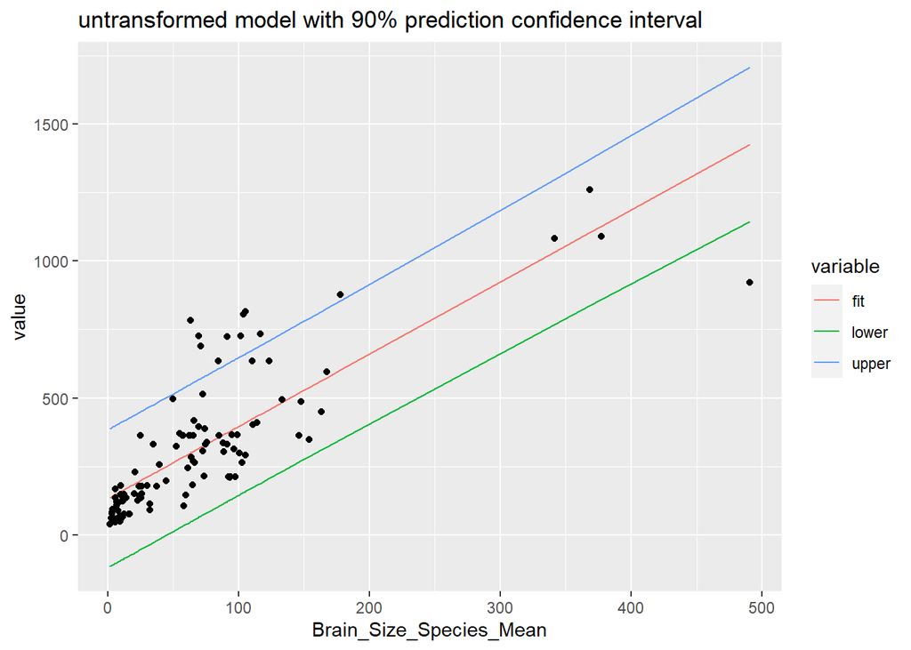

```r
p <- data.frame(df_lm[['Brain_Size_Species_Mean']])
names(p) <- 'Brain_Size_Species_Mean'

pi <- predict(lm_m, newdata = p, interval = 'prediction', level = 0.9)
pi <- cbind(df_lm$Brain_Size_Species_Mean, data.frame(pi))
names(pi) = c('Brain_Size_Species_Mean', 'fit', 'lower', 'upper')
df_pi <- melt(pi, id = 'Brain_Size_Species_Mean')

ggplot(data <- df_pi) +
  geom_line(aes(x = Brain_Size_Species_Mean, y = value, color = variable)) +
  geom_point(data = df_lm, aes(x = Brain_Size_Species_Mean, y = WeaningAge_d))+
  ggtitle("untransformed model with 90% prediction confidence interval")
```

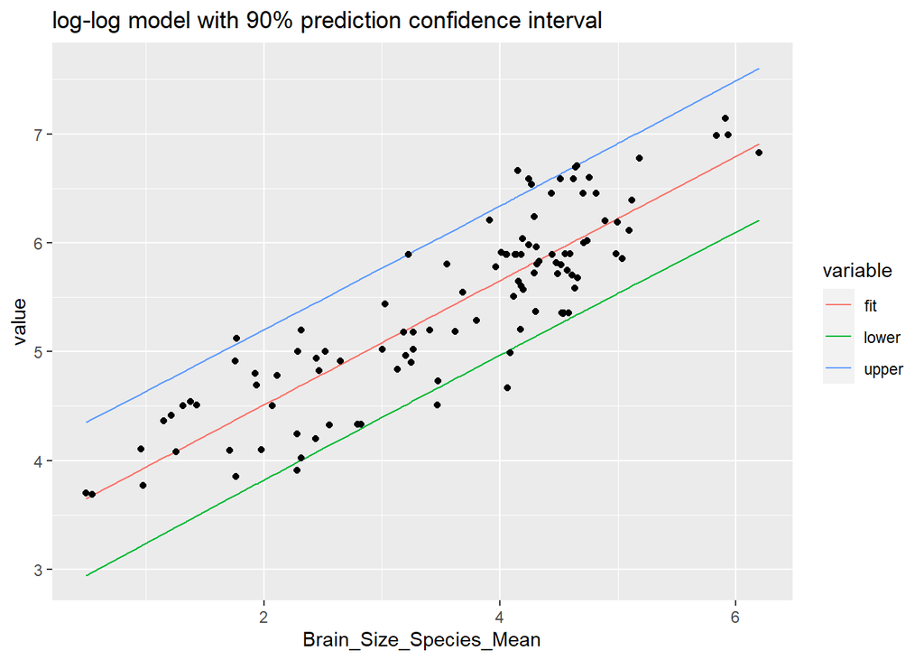

```r
p <- data.frame(df_lm[['Brain_Size_Species_Mean']])
names(p) <- 'Brain_Size_Species_Mean'

pi <- predict(log_m, newdata = p, interval = 'prediction', level = 0.9)
pi <- cbind(log(p), data.frame(pi))
names(pi) <- c('Brain_Size_Species_Mean', 'fit', 'lower', 'upper')
df_pi <- melt(pi, id = 'Brain_Size_Species_Mean')

ggplot(data = df_pi) +
  geom_line(aes(x = Brain_Size_Species_Mean, y = value, color = variable)) +
  geom_point(data = df_lm, aes(x = log(Brain_Size_Species_Mean), y = log(WeaningAge_d))) +
  ggtitle("log-log model with 90% prediction confidence interval")
```

Produce a point estimate and associated 90% prediction interval for the weaning age of a species whose brain weight is 750 gm. Do you trust the model to predict observations accurately for this value of the explanatory variable? Why or why not?

```r
p_estmate <- predict(lm_m, newdata = data.frame(Brain_Size_Species_Mean = 750), interval = 'confidence', level = 0.9)
p_estmate
```

```
##        fit     lwr      upr
## 1 2110.294 1900.04 2320.548
```

```r
p_estmate_log <- exp(predict(log_m, newdata = data.frame(Brain_Size_Species_Mean = 750), interval = 'confidence', level = 0.9))
p_estmate_log
```

```
##        fit      lwr      upr
## 1 1275.339 1079.018 1507.379
```

```r
#I do not trust the model to predict observations accurately for 750gm as most of the data is far away from the mean of the X.
```

Looking at your two models (i.e., untransformed versus log-log transformed), which do you think is better? Why?

```r
#The log-log transformed model seems to be better at representing a true minimization residuals and a normal distribution of data points at all values of the explanatory variable plotted.
```

Challenge 2

Run a linear regression looking at log(MeanGroupSize) in relation to log(Body_mass_female_mean) and report your β coeffiecients (slope and intercept).

```r
lm1 <- lm(log(MeanGroupSize) ~ log(Body_mass_female_mean), data = df)
lm1[["coefficients"]]
```

```
##                (Intercept) log(Body_mass_female_mean)
##                 -1.7772580                  0.5062813
```

Use bootstrapping to sample from the dataset 1000 times with replacement, each time fitting the same model and calculating the appropriate coefficients. Plot a histogram of these sampling distributions for β0 and β1.

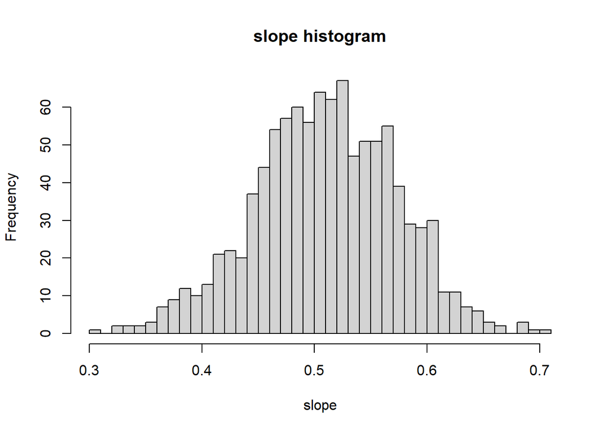

```r
df_b <- df[c('MeanGroupSize', 'Body_mass_female_mean')]
slope <- list()
intercept = list()
for (i in 1:1000){
  df_d = sample_n(df_b, nrow(df_b), replace = TRUE)
  linear_t = lm(log(MeanGroupSize) ~ log(Body_mass_female_mean), data = df_d)
  coef = linear_t[['coefficients']]
  intercept[[i]] = coef[['(Intercept)']]
  slope[[i]] = coef[['log(Body_mass_female_mean)']]
}
intercept <- as.numeric(matrix(intercept))
slope <- as.numeric(matrix(slope))
df_coef <- data.frame(intercept)
df_coef[['slope']] = slope

a <- hist(slope, breaks = 30, main = "slope histogram")
```

```r
a
```

```
## $breaks
##  [1] 0.30 0.31 0.32 0.33 0.34 0.35 0.36 0.37 0.38 0.39 0.40 0.41 0.42 0.43 0.44
## [16] 0.45 0.46 0.47 0.48 0.49 0.50 0.51 0.52 0.53 0.54 0.55 0.56 0.57 0.58 0.59
## [31] 0.60 0.61 0.62 0.63 0.64 0.65 0.66 0.67 0.68 0.69 0.70 0.71
##
## $counts
##  [1]  1  0  2  2  2  3  7  9 12 10 13 21 22 20 37 44 54 57 60 56 64 62 67 47 51
## [26] 51 55 39 29 28 30 11 11  7  6  3  2  0  3  1  1
##
## $density
##  [1] 0.1 0.0 0.2 0.2 0.2 0.3 0.7 0.9 1.2 1.0 1.3 2.1 2.2 2.0 3.7 4.4 5.4 5.7 6.0
## [20] 5.6 6.4 6.2 6.7 4.7 5.1 5.1 5.5 3.9 2.9 2.8 3.0 1.1 1.1 0.7 0.6 0.3 0.2 0.0
## [39] 0.3 0.1 0.1
##
## $mids
##  [1] 0.305 0.315 0.325 0.335 0.345 0.355 0.365 0.375 0.385 0.395 0.405 0.415
## [13] 0.425 0.435 0.445 0.455 0.465 0.475 0.485 0.495 0.505 0.515 0.525 0.535
## [25] 0.545 0.555 0.565 0.575 0.585 0.595 0.605 0.615 0.625 0.635 0.645 0.655
## [37] 0.665 0.675 0.685 0.695 0.705
##
## $xname
## [1] "slope"
##
## $equidist
## [1] TRUE
##
## attr(,"class")
## [1] "histogram"
```

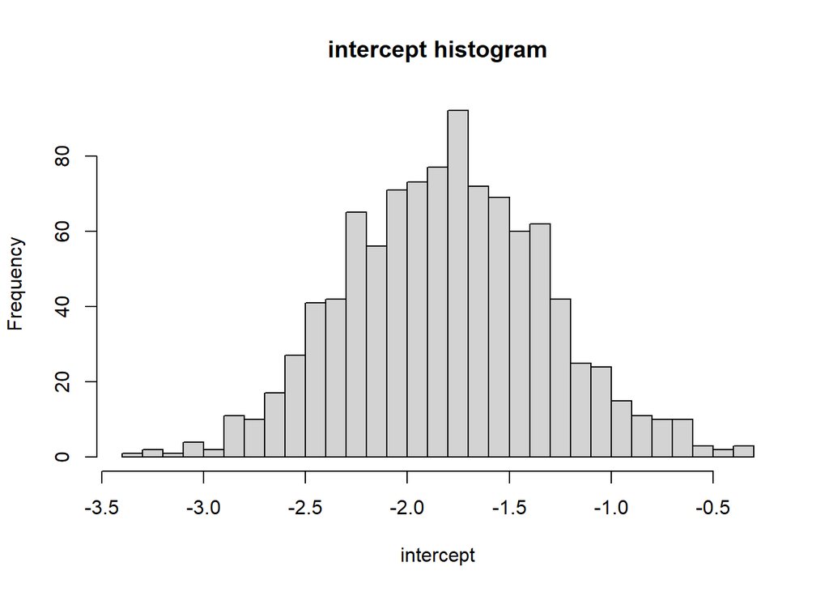

```r
b <- hist(intercept, breaks = 30, main = "intercept histogram")
```

```r
b
```

```
## $breaks
##  [1] -3.4 -3.3 -3.2 -3.1 -3.0 -2.9 -2.8 -2.7 -2.6 -2.5 -2.4 -2.3 -2.2 -2.1 -2.0
## [16] -1.9 -1.8 -1.7 -1.6 -1.5 -1.4 -1.3 -1.2 -1.1 -1.0 -0.9 -0.8 -0.7 -0.6 -0.5
## [31] -0.4 -0.3
##
## $counts
##  [1]  1  2  1  4  2 11 10 17 27 41 42 65 56 71 73 77 92 72 69 60 62 42 25 24 15
## [26] 11 10 10  3  2  3
##
## $density
##  [1] 0.01 0.02 0.01 0.04 0.02 0.11 0.10 0.17 0.27 0.41 0.42 0.65 0.56 0.71 0.73
## [16] 0.77 0.92 0.72 0.69 0.60 0.62 0.42 0.25 0.24 0.15 0.11 0.10 0.10 0.03 0.02
## [31] 0.03
##
## $mids
##  [1] -3.35 -3.25 -3.15 -3.05 -2.95 -2.85 -2.75 -2.65 -2.55 -2.45 -2.35 -2.25
## [13] -2.15 -2.05 -1.95 -1.85 -1.75 -1.65 -1.55 -1.45 -1.35 -1.25 -1.15 -1.05
## [25] -0.95 -0.85 -0.75 -0.65 -0.55 -0.45 -0.35
##
## $xname
## [1] "intercept"
##
## $equidist
## [1] TRUE
##
## attr(,"class")
## [1] "histogram"
```

Estimate the standard error for coefficients as the standard deviation of the sampling distribution from your bootstrap.

```r
intercept_sd <- sd(df_coef[['intercept']])
slope_sd <- sd(df_coef[['slope']])
(paste("standard deviation of intercept:", intercept_sd))
```

```
## [1] "standard deviation of intercept: 0.494876787016274"
```

```r
(paste("standard deviation of slope:", slope_sd))
```

```
## [1] "standard deviation of slope: 0.0632334977019222"
```

Determine the 95% CI for each of your β coefficients based on the appropriate quantiles from your sampling distribution.

```r
intercept_ci <- quantile(df_coef[['intercept']], probs = c(0.025, 0.975))
slope_ci <- quantile(df_coef[['slope']], probs = c(0.025, 0.975))
```

How do the SEs estimated from the bootstrap sampling distribution compare to those estimated mathematically as part of lm() function?

```r
summary(lm1)[['coefficients']]
```

```
##                              Estimate Std. Error   t value     Pr(>|t|)
## (Intercept)                -1.7772580 0.43751572 -4.062158 8.061483e-05
## log(Body_mass_female_mean)  0.5062813 0.05562507  9.101674 8.078462e-16
```

```r
#The SEs estimated via the bootstrap sampling distribution are similar to those estimated via the lm() function.
```

How do bootstrap CIs compare to those estimated mathematically as part of the lm() function?

```r
confint(lm1, level = 0.95)
```

```
##                                 2.5 %     97.5 %
## (Intercept)                -2.6422501 -0.9122659
## log(Body_mass_female_mean)  0.3963075  0.6162550
```

```r
#The CIs estimated via the bootstrap sampling distribution are also similar to those estimated via the lm() function.
```

[output not shown]

Challenge 3

```r
boot_lm <- function(d, model, conf.level = 0.95, reps = 1000)  {
  # Construct dataframe for storing bootstrap results
  df <- data.frame(Coefficient = c("beta0", "beta1"),
                   Coefficientvalue = c(0,0),
                   SE = c(0,0),
                   UprCI = c(0,0),
                   LwrCI = c(0,0),
                   MeanBetaBoot = c(0,0),
                   SEBoot = c(0,0),
                   UprCIBoot = c(0,0),
                   LwrCIBoot = c(0,0))

  m <- lm(eval(parse(text = model)), data = d)

  mtidy <- tidy(m)
  df$Coefficientvalue[1] <- as.numeric(mtidy[1,2])
  df$Coefficientvalue[2] <- as.numeric(mtidy[2,2])
  df$SE[1] <- as.numeric(mtidy[1,3])
  df$SE[2] <- as.numeric(mtidy[2,3])
  modelCI <- confint(m, level = conf.level)
  df$UprCI[1] <- modelCI[1,2]
  df$UprCI[2] <- modelCI[2,2]
  df$LwrCI[1] <- modelCI[1,1]
  df$LwrCI[1] <- modelCI[2,1]

  bootstrap <- data.frame(beta0 = 1:reps, beta1 = 1:reps)
  n <- nrow(d)

  # Run boostrap
  for (i in 1:reps){
    s <- sample_n(d, size = n, replace = TRUE)
    mboot <- lm(eval(parse(text = model)), data = s)
    Bootlm <- mboot$coefficients
    beta0 <- as.numeric(Bootlm[1])
    beta1 <- as.numeric(Bootlm[2])
    bootstrap$beta0[[i]] <- beta0
    bootstrap$beta1[[i]] <- beta1
  }
  df$MeanBetaBoot[1] <- mean(bootstrap$beta0)
  df$MeanBetaBoot[2] <- mean(bootstrap$beta1)
  df$SEBoot[1] <- sd(bootstrap$beta0)
  df$SEBoot[2] <- sd(bootstrap$beta1)
  df$UprCIBoot[1] <- quantile(bootstrap$beta0,  probs = (1-conf.level)/2)
  df$UprCIBoot[2] <- quantile(bootstrap$beta1, (1-conf.level)/2)
  df$LwrCIBoot[1] <- quantile(bootstrap$beta0, probs = 1 - (1 - conf.level)/2)
  df$LwrCIBoot[2] <- quantile(bootstrap$beta1, probs = 1 - (1 - conf.level)/2)
  df
}
```

Use the function to run the models

```r
a <- boot_lm(df, "log(MeanGroupSize) ~ log(Body_mass_female_mean)")
a
```

```
##   Coefficient Coefficientvalue         SE      UprCI     LwrCI MeanBetaBoot
## 1       beta0       -1.7772580 0.43751572 -0.9122659 0.3963075   -1.7758752
## 2       beta1        0.5062813 0.05562507  0.6162550 0.0000000    0.5067026
##      SEBoot  UprCIBoot  LwrCIBoot
## 1 0.4912225 -2.7000843 -0.7798232
## 2 0.0627177  0.3790028  0.6251069
```

```r
b <- boot_lm(df, "log(DayLength_km) ~ log(Body_mass_female_mean)")
b
```

```
##   Coefficient Coefficientvalue        SE     UprCI       LwrCI MeanBetaBoot
## 1       beta0       -0.1427624 0.4650068 0.7795764 -0.07347022  -0.13686338
## 2       beta1        0.0389422 0.0566739 0.1513546  0.00000000   0.03842783
##       SEBoot   UprCIBoot LwrCIBoot
## 1 0.44660249 -1.09840106 0.7571716
## 2 0.05655824 -0.07714845 0.1561344
```

```r
c <- boot_lm(df, "log(DayLength_km) ~ log(Body_mass_female_mean) + log(MeanGroupSize)")
c
```

```
##   Coefficient Coefficientvalue         SE      UprCI      LwrCI MeanBetaBoot
## 1       beta0      -0.29916271 0.48590764 0.66663134 -0.2157728  -0.27458744
## 2       beta1      -0.08813683 0.06421586 0.03949915  0.0000000  -0.09301771
##      SEBoot  UprCIBoot  LwrCIBoot
## 1 0.4472889 -1.1636203 0.64155307
## 2 0.0579628 -0.2093389 0.01767959
```